# Beer Reviews Analysis

## Beer Review Analysis via Optimization

In this project, I work with 2,924,163 beer reviews from https://www.ratebeer.com. One entry contains the text of the consumer’s review together with ratings of appearance, aroma, palate, style, taste, and an overall score from 0 to 20. The data also include the name, id and brewer of the beer.

To simplify the response, I will give reviews binary label: 1 for a (positive) review with overall score at least 14, and otherwise 0 for a (negative) review.

```python
import numpy as np
from numpy import random
import math
import sklearn
import sklearn.svm
from sklearn.svm import LinearSVC
import sklearn.cluster
import statistics as stat
import scipy
import json_lines
import json
import string
import re
from gensim import corpora
import scipy.sparse as sparse
import pandas as pd
from sklearn.linear_model import LogisticRegression as LR
from sklearn.model_selection import train_test_split
import copy
import matplotlib.pyplot as plt
import warnings
warnings.filterwarnings('ignore')
```

```python
"""
DATA PROCESSING
I have previously run this code and saved the output.
"""
with open('data/vocab_50.json', 'r') as f:
    vocab = json.load(f)
    p = len(vocab.keys())

f=open('data/labeled.json', 'r')
adf=json_lines.reader(f)
brv=[]
for af in adf:
    brv.append(af)

n = len(brv)

full_data = pd.DataFrame.from_dict(brv)
full_data.to_csv (r'data/full_data.csv', index = None, header=True)

"""
Data Cleaning + Splitting
"""
full_data = pd.DataFrame.from_dict(brv)
full_data.to_csv(r'data/full_data.csv', index = None, header=True)

random.seed(1)
random.shuffle(brv)
dev_data = full_data[:372952]
test_data = full_data[372952:745904]
train_data = full_data[745904:]

dev_data.to_csv(r'data/dev_data.csv', index = None, header=True)
train_data.to_csv(r'data/train_data.csv', index = None, header=True)
test_data.to_csv(r'data/test_data.csv', index = None, header=True)
```

### PART 1

Let us analyze the dataset before proceeding with the classification problem.

First, we will find the mean, median and standard deviation of the entire dataset. Then, we will group the data according to each beer and by each type of brewer before analyzing the results.

From the results, note that acros the whole data, the overall score's mean is 13.2, the median is 14, and SD is 3.35.

When we look at the plots, for different beers and brewer, the mean do take an normal distribution, implying that people like some beers and brewers more than the other beers/brewers, and some less. The Standard deviation also takes a range for both beer and brewer, indicating that people generally do not have the same taste.

```python
full_data = pd.read_csv("data/full_data.csv")
```

```python
#General Summary
print("mean: ", np.mean(full_data["overall"]))
print("Median: ", np.median(full_data["overall"]))
print("SD: ", np.std(full_data["overall"]))

yummy_beer = full_data.groupby(["beer_id"])["overall"].agg(["mean",
                            "median", "std"])
brew = full_data.groupby(["brewer"])["overall"].agg(["mean",
                            "median", "std"])
```

```
mean:  13.198879641948754
Median:  14.0
SD:  3.3523508091652907
```

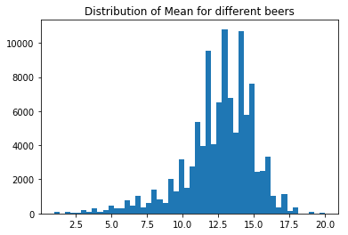

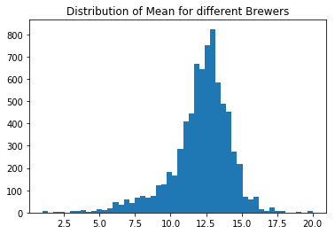

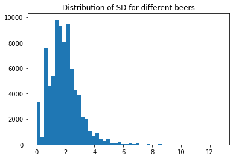

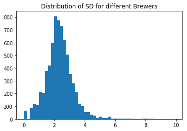

```python
#PLOT THE GROUPED MEAN, MEDIAN AND S.D.
plt.hist(yummy_beer["mean"],bins=50)
plt.title("Distribution of Mean for different beers")
plt.show()

plt.hist(brew["mean"],bins=50)
plt.title("Distribution of Mean for different Brewers")
plt.show()

plt.hist(yummy_beer["std"],bins=50)
plt.title("Distribution of SD for different beers")
plt.show()

plt.hist(brew["std"],bins=50)
plt.title("Distribution of SD for different Brewers")
plt.show()
```

### PART 2

Now, our first task is to classify the sentiment of reviews from the text. Text can have neutral, mixed, sarcastic, or otherwise ambiguous sentiment.

We will start to represent text reviews in terms of a vector of features (covariates). So, each review would be a p-dimensional vector where p is the total size of our dictionary. If a review contains a word, that corresponding space = 1, and the rest are set to 0. To ensure algorithmic efficiency, we reduce our matrix into a sparse matrix.

In this section, we will clean and transform the reviews into a sparse matrix.

```python
#Form into reviews
#I have previously run this code and saved the output.

def clean_and_split(s):
    s = s.lower().replace('-',' ').translate(s.maketrans(" ",
    " ",string.punctuation))
    # replace \r\n
    s = re.sub('(\r\n)+',' ',s)
    s = re.sub(' +',' ',s.strip())
    return s.split(' ')

#Clean the reviews into a list of words
train_cleaned_r = [clean_and_split(review)
                   for review in train_data["review"]]
dev_cleaned_r = [clean_and_split(review)
                 for review in dev_data["review"]]
test_cleaned_r = [clean_and_split(review)
                  for review in test_data["review"]]

dictionary = corpora.Dictionary([vocab.keys()])

#Function to obtain n x p matrix
def obtain_matrix(texts):
    dictionary = corpora.Dictionary([vocab.keys()])
    corpus = [dictionary.doc2bow(text) for text in texts]
    n1 = len(texts)
    p = len(vocab)
    csr_row=[]
    csr_col=[]
    csr_data=[]
    row_id = 0
    for item in corpus:
        for word_id,count in item:
            csr_row.append(row_id)
            csr_col.append(word_id)
            csr_data.append(count)
        row_id += 1
    sparse_mat = sparse.csr_matrix((csr_data,
                                    (csr_row,csr_col)),shape=(n1,p))
    return sparse_mat

dev_reviewmat = obtain_matrix(dev_cleaned_r)
train_reviewmat = obtain_matrix(train_cleaned_r)
test_reviewmat = obtain_matrix(test_cleaned_r)

#Save the matrix
sparse.save_npz("data/dev_reviews.npz",dev_reviewmat)
sparse.save_npz("data/train_reviews.npz",train_reviewmat)
sparse.save_npz("data/test_reviews.npz",test_reviewmat)
```

```python
#Retrieve the data from saved folder
train_data = pd.read_csv("data/train_data.csv")
dev_data = pd.read_csv("data/dev_data.csv")
test_data = pd.read_csv("data/test_data.csv")
```

```python
"""
Input: Review overall score (1 to 20)
Output: Categorical score (1 if review score > 13, 0 otherwise)
"""

def find_binarylabel(data):
    labels = []
    for i in range(len(data['overall'])):
        if data['overall'][i] >= 14:
            label = 1
        else:
            label=0
        labels.append(label)
    return labels

#Labels (response) for development, training and test set
dev_labels = find_binarylabel(dev_data)
train_labels = find_binarylabel(train_data)
test_labels = find_binarylabel(test_data)
```

```python
#Retrieve review matrix from saved document
dev_reviewmat = sparse.load_npz("data/dev_reviews.npz")
dev_labels = np.asarray(dev_labels)
#This step is to filter out observations where all
#columns = 0 in the matrix
dev_labels = dev_labels[dev_reviewmat.getnnz(1)>0]
dev_reviewmat = dev_reviewmat[dev_reviewmat.getnnz(1)>0]

train_reviewmat = sparse.load_npz("data/train_reviews.npz")
train_labels = np.asarray(train_labels)
train_labels = train_labels[train_reviewmat.getnnz(1)>0]
train_reviewmat = train_reviewmat[train_reviewmat.getnnz(1)>0]

test_reviewmat = sparse.load_npz("data/test_reviews.npz")
test_labels = np.asarray(test_labels)
test_labels = test_labels[test_reviewmat.getnnz(1)>0]
test_reviewmat = test_reviewmat[test_reviewmat.getnnz(1)>0]
```

### LOGISTICS REGRESSION

Next, we proceed with logistics regression using Newton's Optimization Method.

We had 2 rounds - first our $\lambda$ list = [0.001, 0.01, 0.1, 1, 10, 100], giving a error array of [0.21232223 0.21219084 0.21219084 0.21222838 0.2122686 0.2122981] respectively. We further tuned, and the best results is given by $\lambda$ = 7, with an error of 0.21219084.

Thereafter, we train the model again, and test it on the test dataset. We also find the time taken to run the training. It takes about 5 minutes, with an error of 0.2102.

```python
lambda_list = [5, 6, 7, 8, 9, 10]
score_list = np.zeros(len(lambda_list))
for pos in range(len(lambda_list)):
    lambda_now = lambda_list[pos]
    clf = LR(solver='newton-cg',
        C = 1/lambda_now).fit(train_reviewmat, train_labels)
    score = clf.score(dev_reviewmat, dev_labels)
    score_list[pos] = score
    print("Done!", pos)

print(lambda_list)
#Print error rate
print(1 - score_list)
```

[output not shown]

```python
import time

begin = time.time()
clf = LR(solver='newton-cg',C = 1/7).fit(train_reviewmat, train_labels)
stop = time.time() - begin

print(stop)
score = clf.score(test_reviewmat, test_labels)
print(1-score)
```

```
301.33694219589233
0.2102468230497111
```

### Linear SVC Class

Then, we retrain and test the model on the test set. We spent a total of 136s, with an error of 0.2106, which is about twice as fast as above.

```python
lambda_list2 = [5, 15, 25, 30, 50]
score_list2 = np.zeros(len(lambda_list2))
for pos in range(len(lambda_list2)):
    lambda_now = lambda_list2[pos]
    clf2 = LinearSVC(penalty="l2", C = 1/lambda_now,
           loss="hinge").fit(train_reviewmat, train_labels)
    score = clf2.score(dev_reviewmat, dev_labels)
    score_list2[pos] = score
    print("Done!", pos)

print(lambda_list2)
#Print error rate
print(1 - score_list2)
```

```
[5, 15, 25, 30, 50]
[0.21300864, 0.2127137, 0.21277805, 0.21313467, 0.21327946]
```

```python
import time

begin = time.time()
clf2 = LinearSVC(penalty="l2", C=1/15,
                 loss="hinge").fit(train_reviewmat, train_labels)
stop = time.time() - begin

print(stop)
score = clf2.score(test_reviewmat, test_labels)
print(1-score)
```

```
136.0153844356537
0.21063093118017895
```

### STOCHASTIC GRADIENT DESCENT

Next, we will train an L2-regularized logistic regression classifier using stochastic gradient descent.

We proceed with writing the stochastic gradient descent function. For the tuning, we set the size of the training set to be around 52K, and the validation to be around 12K.

```python
#First define training set and validation set for the tuning
random.seed(1)
train_small, big_x, labels_small, big_y =
train_test_split(train_reviewmat, train_labels, train_size=0.03)
valid_small, bigg_x, labels_valid, bigg_y =
train_test_split(big_x, big_y, train_size=0.005)

###X,Y are the TUNING training set
X = train_small
Y = labels_small
##TUNING validation set
X_test = valid_small
Y_test = labels_valid
```

Next, we will proceed with the functions. First, we will have the cost function, and the error function, calculated with the estimated $\theta$, X and Y. We also define a SGD function, with a constant learning rate. For demonstration purposes, we will only limit the number of iterations (here defined as number of epoch) = 200.

```python
def  cal_cost(theta, X, Y, lamb):
    '''
    Calculates the cost for given X and Y.
    theta = Vector of thetas
    where j is the number of features
    '''
    firstpart = sum(np.logaddexp(0,X @ theta))
    secondpart = (Y.T @ X @ theta)
    penalty = lamb*np.linalg.norm(theta)*np.linalg.norm(theta)
    return firstpart - secondpart + penalty


def cal_error(theta, X, Y):
    '''
    Calculates the prediction error given X and Y.
    theta = Vector of thetas
    '''
    eta = X.dot(theta)

    #Calculate pi
    pi = np.exp(eta) / (1 + np.exp(eta))
    prediction = np.zeros(len(Y))

    #Rule: if pi > 0.5, then classify 1, o.w. 0
    for i in range(len(Y)):
        if pi[i] >= 0.5:
            prediction[i] = 1
    error = sum(Y != prediction) / len(Y)
    return error
```

```python
"""
Constant Learning Rate
Fix number of iterations = 200
"""

def mini_gradient_descent_constant(X, Y, X_test, Y_test, theta, lamb,
                          learning_rate = 10,
                          iterations=200,
                          batch_size = 32):
    '''
    X    = Matrix of X
    Y    = Vector of Y
    X_test + Y_test = validation set
    theta = Vector of thetas
    learning_rate  = constant
    iterations = number of epoches

    Returns the final theta vector, and array of cost history, and
    array of errors over no of iterations for BOTH training and
    validation set
    '''
    n = len(Y)

    cost_history = [0]
    valid_cost_history = [0]
    error_history = [0]
    valid_error_history = [0]
    difference = 100000000
    iteration = 0

    for it in range(iterations):
        iteration += 1
        cost = 0.0
        valid_cost = 0.0
        indices = np.random.permutation(n)
        X = X[indices]
        Y = np.array(Y)[indices]
        for i in range(0, n, batch_size):
            X_i = X[i:i+batch_size]
            Y_i = Y[i:i+batch_size]
            #Y_i = np.ndarray.tolist(Y_i)

            full_X_i = X_i

            #Derivative of Loss
            firstpart = np.array(Y_i*full_X_i)
            firstpart = firstpart.reshape((len(X_i[0,:],1))

            eta_batch = full_X_i.dot(theta)
            exp_term = np.exp(eta_batch)/(1 + np.exp(eta_batch))
            secondpart = full_X_i.T.dot(exp_term)

            thirdpart = 2*lamb*theta

            loss_diff = -firstpart + secondpart + thirdpart
            theta = theta -(1/batch_size)*learning_rate*loss_diff

            cost += cal_cost(theta, X_i, Y_i, lamb)


        cost_history.append(cost.astype(float))
        difference = abs(cost_history[-1] - cost_history[-2])

        valid_cost = cal_cost(theta, X_test, Y_test, lamb)
        valid_cost_history.append(valid_cost)
        error_train = cal_error(theta, X, Y)
        error_history.append(error_train)
        error_valid = cal_error(theta, X_test, Y_test)
        valid_error_history.append(error_valid)

        if iteration %5 == 0:
            print(iteration, difference, cost)
            print(error_valid)

    return theta, cost_history,
           valid_cost_history, error_history, valid_error_history
```

```python
"""
Perform the SGD
Fix learning rate = 10
"""
random.seed(1)
rate = 10
lamb_input = 0.0001
theta = np.random.randn(30009,1)

theta, cost_history, valid_cost_hist, error_hist,
valid_error = mini_gradient_descent_constant(X, Y,
                            X_test, Y_test, theta,
                            lamb_input, batch_size =50)
```

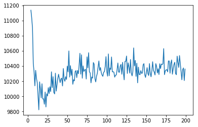

```python
plt.plot(range(200)[4:], cost_history[4:200])
plt.show()
```

In the plot above, we plot the cost of each iteration/epoch. Notice that for a constant learning rate, there may not be convergence, since the objective value is oscillating. Hence, we will improve upon our function by allowing learning rate = $\frac{k}{t}$, where k is an input constant, and t is the number of iterations. The more iterations we go through, the smaller the steps will be, to allow for convergence.

```python
"""
Define new SGD function, where the learning rate
is a function of epoch.
"""

def mini_gradient_descent(X, Y, X_test, Y_test, theta, lamb,
                          learning_constant = 5,
                          threshold = 1,
                          batch_size = 100):
    '''
    X    = Matrix of X
    Y    = Vector of labels
    X_test + Y_test = validation set
    theta = Vector of thetas
    learning_constant  = k
    lamb = lambda selected from tuning
    Threshold = minimum difference between cost before convergence

    Returns the final theta vector, and array of cost history, and
    array of errors over no. of iterations for both training and
    validation
    Iteration will stop upon convergence, defined as
        difference between cost < threshold = 1
    '''
    n = len(Y)

    cost_history = [0]
    valid_cost_history = [0]
    error_history = [0]
    valid_error_history = [0]
    difference = 100000000
    iteration = 0

    while difference > threshold:
        iteration += 1
        learning_rate = learning_constant/iteration
        cost = 0.0
        valid_cost = 0.0
        indices = np.random.permutation(n)
        X = X[indices]
        Y = np.array(Y)[indices]
        for i in range(0, n, batch_size):
            X_i = X[i:i+batch_size]
            Y_i = Y[i:i+batch_size]

            full_X_i = X_i

            #Derivative of Loss
            firstpart = np.array(Y_i).dot(full_X_i)
            firstpart = firstpart.reshape((len(X_i[0,:])),1)
            eta_batch = full_X_i.dot(theta)
            exp_term = np.exp(eta_batch)/(1 + np.exp(eta_batch))
            secondpart = full_X_i.T.dot(exp_term)
            thirdpart = 2*lamb*theta
            loss_diff = -firstpart + secondpart + thirdpart

            #Update theta
            theta = theta -(1/batch_size)*learning_rate*loss_diff

            #Update cost
            cost += cal_cost(theta, X_i, Y_i, lamb)


        cost_history.append(cost)
        #Calculate new difference
        difference = abs(cost_history[-1] - cost_history[-2])

        #Record all the values we want to measure
        valid_cost = cal_cost(theta, X_test, Y_test, lamb)
        valid_cost_history.append(valid_cost)
        error_train = cal_error(theta, X, Y)
        error_history.append(error_train)
        error_valid = cal_error(theta, X_test, Y_test)
        valid_error_history.append(error_valid)

        #Print info to keep track
        if iteration %5 == 0:
            print(iteration, difference)
            print(error_valid)

    return theta, cost_history, valid_cost_history,
           error_history, valid_error_history
```

```python
"""
Here, we will perform our tuning on a smaller dataset
"""

random.seed(1)
rate = 5
theta = np.random.randn(30009,1)

lamb_trial = [0.00001, 0.0001, 0.001, 0.01, 0.1, 1]

for lamb_try in lamb_trial:
    lamb_input = lamb_try
    theta, cost_history, valid_cost_hist, error_hist,
    valid_error = mini_gradient_descent(X, Y,
                              X_test, Y_test, theta,
                              lamb_input, threshold= 1,
                              learning_constant = rate,
                              batch_size =50)

    print('Lambda value: ', lamb_try)
    print('Final cost/MSE:'.format(np.array(cost_history)[-1]))
    print('Final Error '.format(np.array(valid_error)[-1]))
```

```
Lambda value:  1e-05
Final cost/MSE:  19468.550
Final Error (validation):  0.256
Lambda value:  0.0001
Final cost/MSE:  19489.885
Final Error (validation):  0.255
Lambda value:  0.001
Final cost/MSE:  22083.320
Final Error (validation):  0.235
Lambda value:  0.01
Final cost/MSE:  24007.138
Final Error (validation):  0.223
Lambda value:  0.1
Final cost/MSE:  27398.252
Final Error (validation):  0.239
Lambda value:  1
Final cost/MSE:  31534.763
Final Error (validation):  0.271
```

From the results, we select $\lambda$ = 0.01, giving an error of 0.223 on the validation set. We will proceed with training our final model.

```python
theta_rand = np.random.randn(30009,1)
#CLEARED OUTPUT TO PREVENT LONG LIST OF ITERATION
#RESULT FROM BEING PRINTED

begin = time.time()
theta_final, cost_history, valid_cost_hist, error_hist,
valid_error = mini_gradient_descent(train_reviewmat,
                             train_labels, dev_reviewmat, dev_labels,
                             theta_rand, 0.01, threshold= 15,
                             learning_constant = 5,
                             batch_size = 1000)
stop = time.time() - begin
```

```
8905.982701539993
0.214085218283547
```

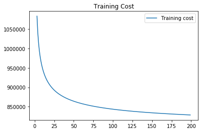

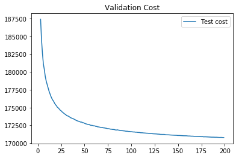

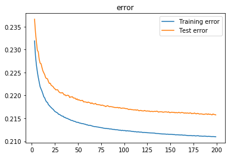

```python
#Time taken for algorithm to run
print(stop)

#Labels should be written "validation" instead of training -
#sorry I lost the data when the kernel restart and I don't
#want to run it again just to change the plot

#Print final test error
print(cal_error(theta, test_reviewmat, test_labels))

plt.plot(range(len(cost_history))[3:200], cost_history[3:200],
         label="Training cost")
plt.legend(); plt.title("Training Cost")
plt.show()

plt.plot(range(len(valid_cost_hist))[3:200], valid_cost_hist[3:200],
         label="Test cost")
plt.legend(); plt.title("Validation Cost")
plt.show()

plt.plot(range(len(error_hist))[3:200], error_hist[3:200],
         label="Training error")
plt.plot(range(len(valid_error))[3:200], valid_error[3:200],
         label="Test error")
plt.legend(); plt.title("error")
plt.show()
```

Observe that we took more than 2 hours for the algorithm to converge. Nontheless, we can probably make it faster if we set a higher convergence threshold instead of 15. Some trends are that the training error is lower than the test error, with obvious reasons.

In addition, the test error is 0.2140, which is slightly higher than the previous question's Logistics Regression function of 0.2102 and SVC's 0.2106, although the difference is not significant.

### PART 3

Now, we proceed to the last part. We will first retrieve the relevant information from the dataset, before scaling the Xs by subtracting the mean and dividing the S.D. We will start the tune the data on a smaller dataset. For the tuning, we set the size of the training set to be around 52K, and the validation to be around 12K.

```python
dev_labels = np.array(find_binarylabel(dev_data))
train_labels = np.array(find_binarylabel(train_data))
test_labels = np.array(find_binarylabel(test_data))

train_data = pd.read_csv("data/train_data.csv")
dev_data = pd.read_csv("data/dev_data.csv")
test_data = pd.read_csv("data/test_data.csv")


def fill_matrix(df, Y):
    mat = np.zeros((len(Y), 5))
    mat[:, 0] = df['appearance']
    mat[:, 1] = df['aroma']
    mat[:, 2] = df['palate']
    mat[:, 3] = df['style']
    mat[:, 4] = df['taste']
    return mat

dev_mat = fill_matrix(dev_data, dev_labels)
train_mat = fill_matrix(train_data, train_labels)
test_mat = fill_matrix(test_data, test_labels)

from sklearn.preprocessing import StandardScaler
scaler = StandardScaler()
scaler.fit(train_mat)
new_train = scaler.transform(train_mat)
new_dev = scaler.transform(dev_mat)
new_test = scaler.transform(test_mat)
```

```python
#First define training set and validation set for the tuning
random.seed(1)
train_small, big_x, labels_small, big_y = train_test_split(new_train,
                                    train_labels, train_size=0.03)
valid_small, bigg_x, labels_valid, bigg_y = train_test_split(big_x,
                                    big_y, train_size=0.005)

###X,Y are the tuning training set
X = train_small
Y = labels_small
##tuning validation set
X_test = valid_small
Y_test = labels_valid
```

```python
"""
Here, we will perform our tuning on a smaller dataset
"""

random.seed(1)
rate = 1
theta = np.random.randn(5,1)

lamb_trial = [0.001, 0.005, 0.01, 0.1, 0.5, 1, 5, 10]

for lamb_try in lamb_trial:
    lamb_input = lamb_try
    theta, cost_history, valid_cost_hist, error_hist,
    valid_error = mini_gradient_descent(X, Y,
                              X_test, Y_test, theta,
                              lamb_input, threshold = 1,
                              learning_constant = rate,
                              batch_size =50)

    print('Lambda value: ', lamb_try)
    print('Final cost/MSE: '.format(np.array(cost_history)[-1]))
    print('Final Error (validation):'.format(np.array(valid_error)[-1]))
```

```
Lambda value:  0.001
Final cost/MSE:  17626.438
Final Error (validation):  0.142
Lambda value:  0.005
Final cost/MSE:  17644.034
Final Error (validation):  0.143
Lambda value:  0.01
Final cost/MSE:  17685.247
Final Error (validation):  0.143
Lambda value:  0.1
Final cost/MSE:  18213.921
Final Error (validation):  0.142
Lambda value:  0.5
Final cost/MSE:  19799.191
Final Error (validation):  0.144
Lambda value:  1
Final cost/MSE:  21085.124
Final Error (validation):  0.143
Lambda value:  5
Final cost/MSE:  25739.871
Final Error (validation):  0.147
Lambda value:  10
Final cost/MSE:  28168.870
Final Error (validation):  0.149
```

From the results, we will take $\lambda = 0.1$ (although in this case, the differences between different $\lambda$ are not large. Here, we continue to use a learning rate that decreases with every epoch, and the constant value k = 1.

```python
#Merge training and Validation set
final_train = np.concatenate((new_train, new_dev))
final_labels = np.concatenate((train_labels, dev_labels))
```

```python
"""
Train the final model
"""
import time
#Initialize random theta
theta_rand = np.random.randn(5,1)

begin = time.time()
theta_final2, cost_history2, test_cost_hist2,
error_hist2, test_error2 = mini_gradient_descent(final_train,
                             final_labels, new_test, test_labels,
                             theta_rand, 0.1, threshold= 5,
                             learning_constant = 1,
                             batch_size = 1000)
stop = time.time() - begin
```

```
5 [26.34447496]
0.14609386730732105
```

```python
print("Test Error: ", test_error2[-1])
print("Time Taken: ", stop)
```

```
Test Error:  0.1461072738582981
Time Taken:  88.08180212974548
```

Observe that the model using the scores perform much better than the reviews, with only an error rate of 0.146 compared to 0.214 above.

This is because firstly, the reviews contain much more dimensions (30K), so the chance of error is higher compared to a lower-dimensional predictor.

More importantly, recall that the labels are based on (indicator function of) the overall score, which is itself heavily based on the 5 predictors in our scores model - appearance, taste etc. Hence, the correlation of these predictors with the sentiments are much larger than that of reviews, where we also fail to take into account factors like multiple word meaning, word embeddings and language nuances.